# SHAP for XGBoost in R: SHAPforxgboost

- Show All Code
- Hide All Code
- View Source

Author

TigerZ

Published

2023-11-09

## 1 The SHAPforxgboost package

我编写了 R 包 [SHAPforxgboost](https://cran.r-project.org/web/packages/SHAPforxgboost/index.html) 来涵盖本文中介绍的所有绘图函数。这篇文章作为该包的 vignette。

请从 CRAN 或 [Github](https://github.com/liuyanguu/SHAPforxgboost) 安装。

```r
install.packages("SHAPforxgboost")
# or
devtools::install_github("liuyanguu/SHAPforxgboost")
```

## 2 Why SHAP values

SHAP 的主要优点是**局部解释**和全局模型结构的**一致性**。

基于树的机器学习模型（random forest, gradient boosted trees, XGBoost）是当今最流行的非线性模型。SHAP (SHapley Additive exPlanations) 值被认为是解释基于树的模型结果的最先进方法。它基于博弈论中的 Shaply values，并通过对模型结果的边际贡献来表示特征重要性。

此 [Github](https://github.com/slundberg/shap) 页面介绍了 Scott Lundberg 开发的 Python 包。这里我们展示了 R 中的所有可视化。`xgboost::xgb.shap.plot` 函数还可以制作简单的依赖图。

### 2.1 Local explanation

```r
# run the model with built-in data
suppressPackageStartupMessages({
library("SHAPforxgboost"); library("ggplot2"); library("xgboost")
library("data.table"); library("here")
})

y_var <-  "diffcwv"
dataX <- as.matrix(dataXY_df[,-..y_var])
# hyperparameter tuning results
param_list <- list(objective = "reg:squarederror",  # For regression
                   eta = 0.02,
                   max_depth = 10,
                   gamma = 0.01,
                   subsample = 0.95
                   )
mod <- xgboost::xgboost(data = dataX,
                        label = as.matrix(dataXY_df[[y_var]]),
                        params = param_list, nrounds = 10,
                        verbose = FALSE, nthread = parallel::detectCores() - 2,
                        early_stopping_rounds = 8)

# To return the SHAP values and ranked features by mean|SHAP|
shap_values <- shap.values(xgb_model = mod, X_train = dataX)
# The ranked features by mean |SHAP|
shap_values$mean_shap_score
```

```
         dayint       Column_WV AOT_Uncertainty   dist_water_km             aod
   0.0163717002    0.0117889638    0.0071820878    0.0057367337    0.0040513037
           elev     DevAll_P1km           RelAZ  forestProp_1km
   0.0036384439    0.0024570116    0.0009505458    0.0003258387
```

计算 training dataset 中每个单元格的 SHAP 值。SHAP 值数据集 (`shap_values$shap_score`) 与适合 xgboost 模型的自变量数据集 (10148,9) 具有相同的维度 (10148,9)。

SHAP 值每行的总和（加上 BIAS 列，类似于截距）是预测的模型输出。如下表 SHAP 值所示，`rowSum` 等于输出预测(xgb_mod)。即，解释的归因值总计为模型输出（下表的最后一列）。本例就是这种情况，但如果您正在运行例如 5-fold 交叉验证，则情况并非如此。

```r
# to show that `rowSum` is the output:
shap_data <- copy(shap_values$shap_score)
shap_data[, BIAS := shap_values$BIAS0]
pred_mod <- predict(mod, dataX, ntreelimit = 10)
```

```
[21:11:58] WARNING: src/c_api/c_api.cc:935: `ntree_limit` is deprecated, use `iteration_range` instead.
```

```r
shap_data[, `:=`(rowSum = round(rowSums(shap_data),6), pred_mod = round(pred_mod,6))]
rmarkdown::paged_table(shap_data[1:20,])
```

| dayint | Column_WV | AOT_Uncertainty | elev | aod | RelAZ | DevAll_P1km | dist_water_km | forestProp_1km | BIAS | rowSum | pred_mod |
| --- | --- | --- | --- | --- | --- | --- | --- | --- | --- | --- | --- |
| -0.02548757 | 5.202634e-05 | -0.007833229 | 0.0078733107 | -0.0115284175 | -0.0003402718 | -1.669927e-03 | 0.006688195 | 1.256332e-04 | 0.4175124 | 0.385392 | 0.385392 |
| -0.02733733 | -1.047647e-04 | -0.011626832 | -0.0045538773 | -0.0277890675 | -0.0012191039 | -3.031081e-03 | -0.016632417 | -1.528580e-04 | 0.4175124 | 0.325065 | 0.325065 |
| -0.03384849 | -6.153054e-04 | -0.001543404 | -0.0053896480 | -0.0104484502 | -0.0004541901 | 3.311628e-03 | 0.001159923 | 8.486740e-05 | 0.4175124 | 0.369769 | 0.369769 |
| -0.03432611 | -4.194604e-03 | -0.019662527 | -0.0035330444 | -0.0222609602 | -0.0011563945 | 1.602795e-03 | -0.013881115 | 3.186500e-04 | 0.4175124 | 0.320419 | 0.320419 |
| -0.01602108 | -8.699026e-03 | 0.004172986 | 0.0040074284 | 0.0009812004 | -0.0002829637 | -2.320216e-05 | 0.001967464 | 1.219463e-04 | 0.4175124 | 0.403737 | 0.403737 |
| -0.01739999 | -1.099652e-03 | 0.001121991 | -0.0016766908 | 0.0018713353 | -0.0002592074 | 1.503672e-03 | -0.002207198 | 4.576208e-04 | 0.4175124 | 0.399824 | 0.399824 |
| -0.01954954 | -5.389351e-03 | 0.001102879 | -0.0041278466 | 0.0011803010 | -0.0002536120 | 1.413768e-03 | -0.001732612 | 1.135089e-04 | 0.4175124 | 0.390270 | 0.390270 |
| -0.01417042 | -3.492416e-03 | -0.006197749 | 0.0029136867 | 0.0041323393 | -0.0002087356 | 1.638217e-04 | 0.001789461 | 1.062852e-04 | 0.4175124 | 0.402549 | 0.402549 |
| -0.01434688 | 4.116213e-03 | -0.005358510 | -0.0017213894 | 0.0038591875 | -0.0002943158 | -9.622768e-05 | -0.003793251 | -5.293884e-05 | 0.4175124 | 0.399824 | 0.399824 |
| -0.01481600 | 6.889687e-04 | -0.005662199 | -0.0005251614 | 0.0037992438 | -0.0001840962 | 1.405217e-03 | -0.002620797 | 2.267109e-04 | 0.4175124 | 0.399824 | 0.399824 |

[output cut: 10 more lines]

这为数据集中的每个观察提供了模型解释。在总结整个模型时提供了很大的灵活性。

### 2.2 Consistency in global feature importance

为什么 Gain 的特征重要性不一致

一致性意味着比较不同模型之间的特征重要性是合法的。当我们修改模型以使某个特征更加重要时，该特征的重要性应该会增加。该论文使用了以下示例：

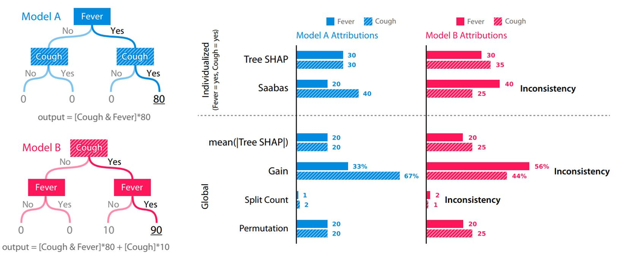

SHAPsuppfig2.JPG

paper 2, [S. Lundberg 2019 arXiv:1905.04610](https://arxiv.org/abs/1905.04610)

使用上面模型 A 的数据集作为一个简单的示例，哪个特征首先进入数据集会通过 Gain 生成相反的特征重要性：无论哪个特征较晚（在树中较低的位置）都会获得更多的信用。请注意，下面 `xgb.importance` 中的功能重要性已翻转。

```r
library(xgboost)
d <- data.table::as.data.table(cbind(Fever = c(0,0,1,1), Cough = c(0,1,0,1), y = c(0,0,0,80)))
knitr::kable(d)
```

| Fever | Cough | y |
| --- | --- | --- |
| 0 | 0 | 0 |
| 0 | 1 | 0 |
| 1 | 0 | 0 |
| 1 | 1 | 80 |

```r
X1 = as.matrix(d[,.(Fever, Cough)])
X2 = as.matrix(d[,.(Cough, Fever)])
m1 = xgboost(
  data = X1, label = d$y,base_score = 0, gamma = 0, eta = 1, lambda = 0,nrounds = 1, verbose = F)
m2 = xgboost(
  data = X2, label = d$y,base_score = 0, gamma = 0, eta = 1, lambda = 0,nrounds = 1, verbose = F)
xgb.importance(model = m1)
```

```
   Feature      Gain     Cover Frequency
1:   Cough 0.6666667 0.3333333       0.5
2:   Fever 0.3333333 0.6666667       0.5
```

```r
xgb.importance(model = m2)
```

```
   Feature      Gain     Cover Frequency
1:   Fever 0.6666667 0.3333333       0.5
2:   Cough 0.3333333 0.6666667       0.5
```

简而言之，树的构建顺序/结构对于 SHAP 并不重要，但对于 Gain 很重要，并且平均绝对 SHAP 是相同的（20 vs. 20）。

而且，比较上图中的模型 B 和模型 A，模型 B 的输出实际上被修改了，它更多地依赖于给定的特征（Cough，输出分数增加了 10），所以 Cough 应该是一个更重要的特征。虽然 Gain 仍然会出错，但 SHAP 反映了正确的特征重要性。

## 3 SHAP plots

### 3.1 Summary plot

summary plot 显示了全局特征的重要性。sina plots 使用每个观测值的每个特征的 SHAP 值显示特征对模型输出的贡献分布（在本例中为 CWV 测量误差的预测）。每个点都是一个观察结果（station-day）。

```r
# To prepare the long-format data:
shap_long <- shap.prep(xgb_model = mod, X_train = dataX)
# is the same as: using given shap_contrib
shap_long <- shap.prep(shap_contrib = shap_values$shap_score, X_train = dataX)
```

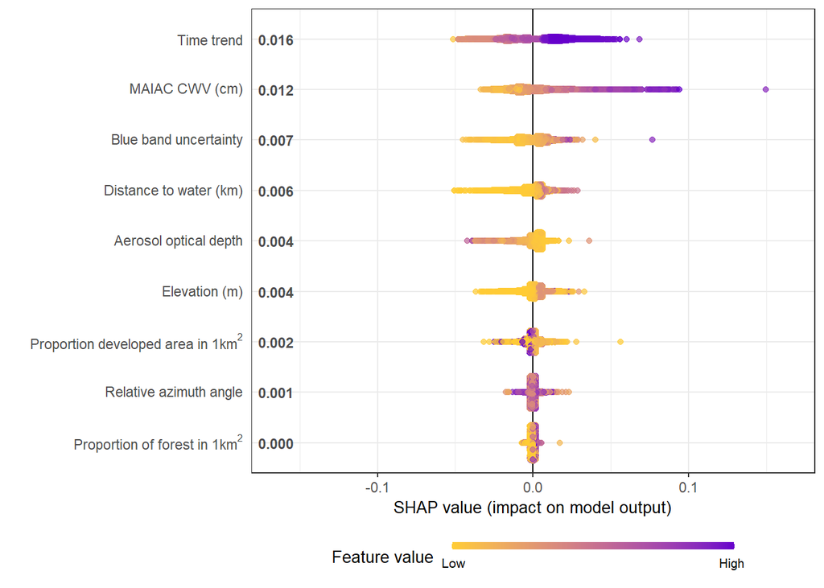

```r
# **SHAP summary plot**
shap.plot.summary(shap_long)
```

制作相同图的其他方法：

```r
# option 1: from the xgboost model
shap.plot.summary.wrap1(model = mod, X = dataX)

# option 2: supply a self-made SHAP values dataset (e.g. sometimes as output from cross-validation)
shap.plot.summary.wrap2(shap_score = shap_values$shap_score, X = dataX)
```

### 3.2 Dependence plot

它根据每个变量的特征值绘制 SHAP 值。同样，每个点都是一个 station-day 观察结果。

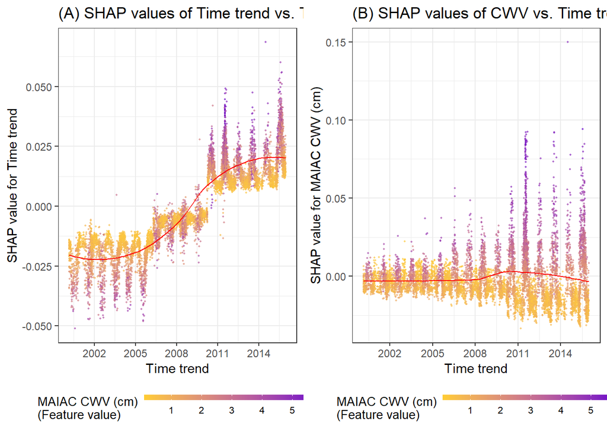

```r
g1 <- shap.plot.dependence(data_long = shap_long, x = 'dayint', y = 'dayint', color_feature = 'Column_WV') + ggtitle("(A) SHAP values of Time trend vs. Time trend")
g2 <- shap.plot.dependence(data_long = shap_long, x = 'dayint', y = 'Column_WV', color_feature = 'Column_WV') +  ggtitle("(B) SHAP values of CWV vs. Time trend")

gridExtra::grid.arrange(g1, g2, ncol = 2)
```

A. SHAP 值显示时间趋势对预测的贡献。颜色代表每次观察的 MAIAC CWV（紫色高，黄色低）。 LOESS（局部估计散点图平滑）曲线以红色覆盖。

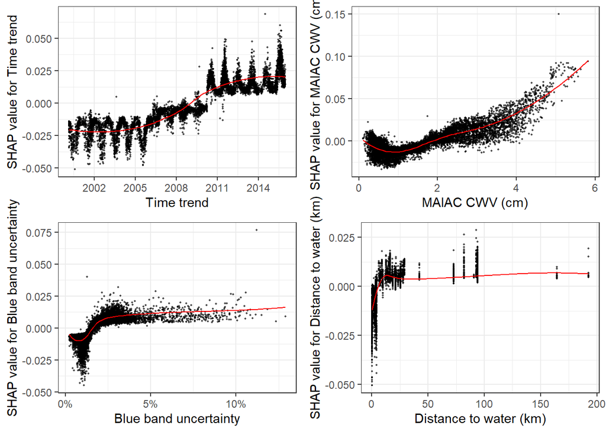

```r
fig_list <- lapply(names(shap_values$mean_shap_score)[1:4],
                   shap.plot.dependence, data_long = shap_long)
gridExtra::grid.arrange(grobs = fig_list, ncol = 2)
```

### 3.3 Interaction effects

SHAP 交互值将变量的影响分为主效应和交互效应。它们粗略地加起来就构成了依赖图。

SHAP 交互值需要时间，因为它计算所有组合。

```r
# prepare the data using either:
# (this step is slow since it calculates all the combinations of features.)
shap_int <- shap.prep.interaction(xgb_mod = mod, X_train = dataX)
# or:
shap_int <- predict(mod, dataX, predinteraction = TRUE) # (the same)
```

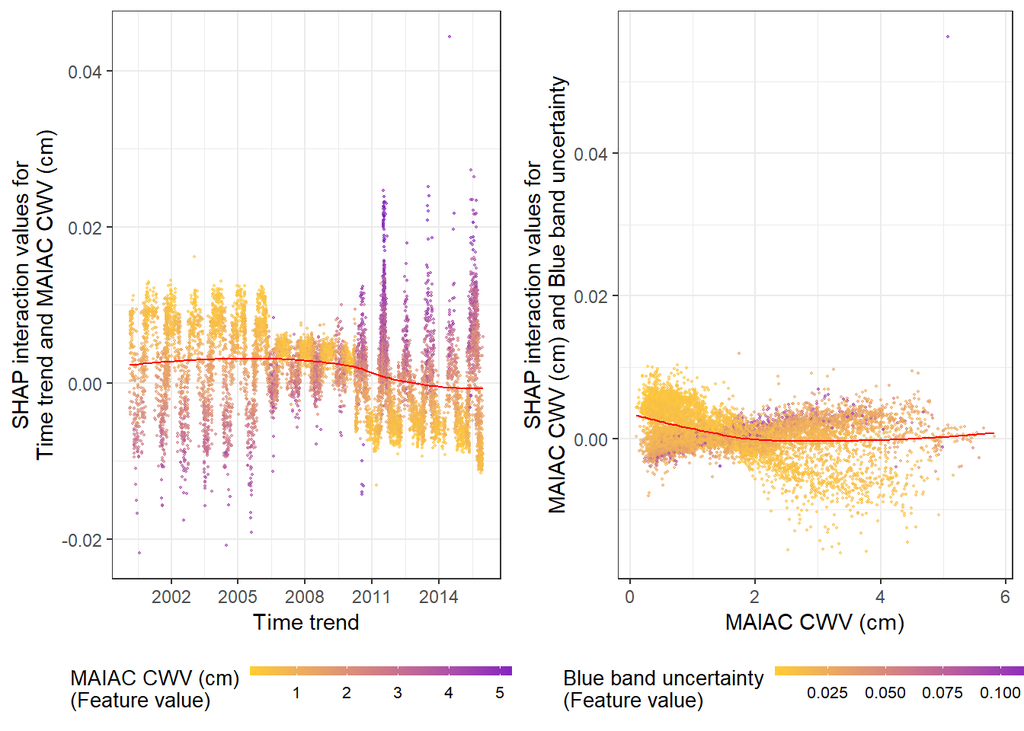

```r
# **SHAP interaction effect plot **
# if `data_int` is supplied, the same function will plot the interaction effect:
g3 <- shap.plot.dependence(data_long = shap_long,
                           data_int = shap_int,
                           x= "dayint", y = "Column_WV",
                           color_feature = "Column_WV")
g4 <- shap.plot.dependence(data_long = shap_long,
                           data_int = shap_int,
                           x= "Column_WV", y = "AOT_Uncertainty",
                           color_feature = "AOT_Uncertainty")
gridExtra::grid.arrange(g3, g4, ncol=2)
```

在这里，我展示了时间趋势和 CWV 之间的交互作用（左），以及蓝带不确定性和 CWV 之间的交互作用（右）。

### 3.4 SHAP force plot

SHAP force plot 基本上堆叠了每个观测的这些 SHAP 值，并显示了如何获得最终输出作为每个预测变量的属性的总和。

```r
# choose to show top 4 features by setting `top_n = 4`,
# set 6 clustering groups of observations.
plot_data <- shap.prep.stack.data(shap_contrib = shap_values$shap_score, top_n = 4, n_groups = 6)
```

```
The SHAP values of the Rest 5 features were summed into variable 'rest_variables'.
```

```
Data has N = 10148 | zoom in length is 150 at location 5000.
```

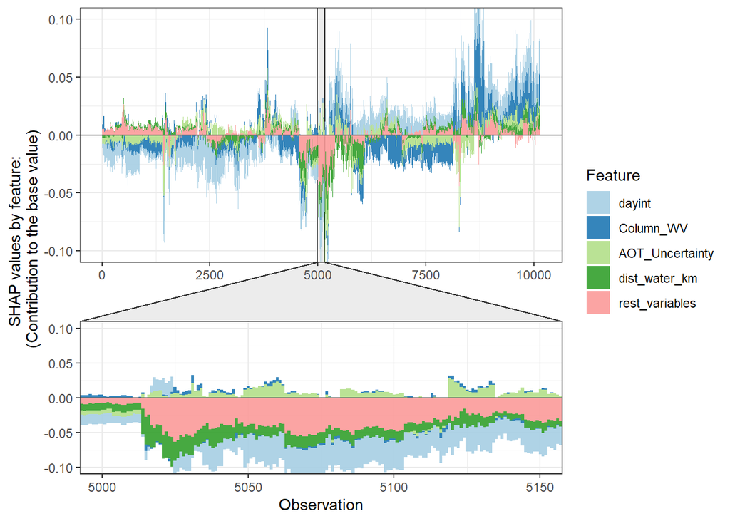

```r
# you may choose to zoom in at a location, and set y-axis limit using `y_parent_limit`
shap.plot.force_plot(plot_data, zoom_in_location = 5000, y_parent_limit = c(-0.1,0.1))
```

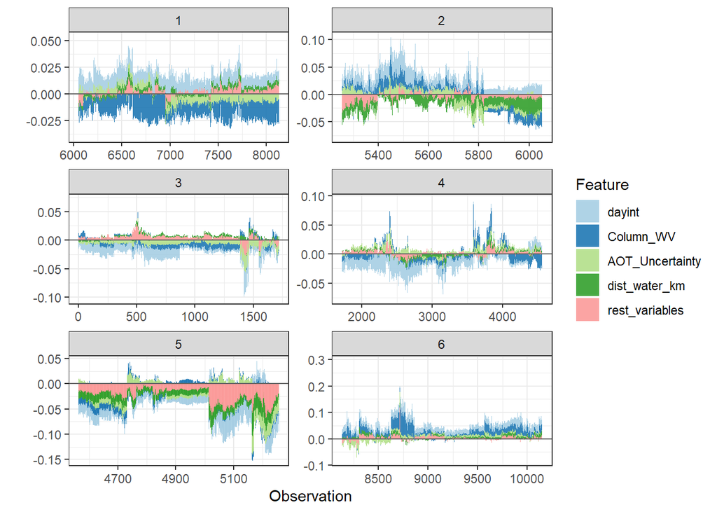

```r
# plot the 6 clusters
shap.plot.force_plot_bygroup(plot_data)
```